# grad_prj_report

## Investigating Mountain Block Recharge in the Missoula Aquifer

*Via Missoula Aquifer Conceptual MODFLOW Model*

Graduate Student Project  
Hydrogeology GEO 420  
Mikaela Bollag-Miller

## 1. Introduction

Mountain groundwater provides a critical, yet often unestimated, source of recharge for alluvial aquifers, which are the major source of freshwater in the intermountain west. Mountain Block Recharge (MBR), lateral groundwater flow from upland mountain blocks into an adjacent basin aquifer, is a key rechange mechanism in semi-arid to arid regions. This study investigates the impact of MBR on the groundwater dynamics within the Missoula Aquifer in the Missoula Valley, a characteristic intermountain basin.

The Missoula Valley is an alluvial basin bordered by high relief mountain blocks, located in Western Montana. It is a wedge-shaped basin that is drained by the Clark Fork and Bitterroot Rivers (LaFave, 2002; Miller, 1991). The Clark Fork River enters the valley from the east through Hellgate Canyon and flows west until it is joined by the south-flowing Rattlesnake Creek, and the north-flowing Bitterroot River. The dominant land use of the study area is primarily urban and residential.

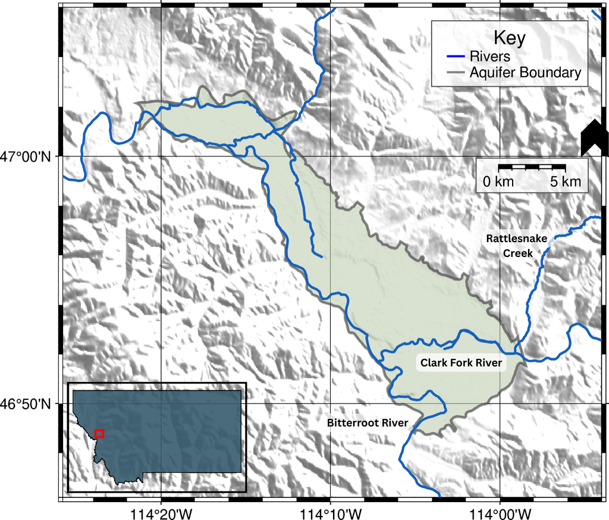

**Figure 1:** Map of the Missoula Valley, Montana, showing major features referenced in this study and the Missoula Aquifer extent.

Missoula, MT has a semiarid climate, with the majority of the precipitation falling during the winter months (LaFave, 2002). The hydrological system in the area is snowmelt dominated, with peak streamflows occurring in concert with early spring snowmelt. Missoula’s average annual rainfall is 13.5 inches, and annual snowfall is 42.5 inches (Brust, n.d.). The mean annual temperature in Missoula is 44.6ºF (Brust, n.d.).

The geological history of Western Montana is underpinned by prolonged tectonic activity; massive Proterozoic sedimentary deposits were altered by Mesozoic orogenic thrusting followed by Cenozoic extension to create an abundance of fractured metasedimentary rock (Belt Supergroup) (Miller, 1991; Pracht, 2001; Smith, 1992). Glacial overprinting in the late Pleistocene carved this region into a basin and range system defined by fault-bounded basin-fill valleys bordered by highly fractured mountain blocks (Pracht, 2001; Smith, 1992). The Missoula Valley itself was inundated by, and subsequently drained of, Glacial Lake Missoula, leaving behind thick, coarse-grained glacial deposits that form much of the modern-day MA (Pracht, 2001).

The principal aquifer in the valley, the Missoula Aquifer (MA), is a highly-productive alluvial basin-fill aquifer which is tightly coupled with the surface water system. The hydrostratigraphy of the Missoula Aquifer is composed of three layers: (1- Top) 10-30 feet of unconsolidated boulder, gravel, and sand deposit, (2- Middle) 40 feet of silty, sandy clay with sand and gravel lenses, (3- Bottom), 50- 100 feet coarse-grained sediments that coarsen with depth (Pracht, 2001). Beneath the aquifer, the lithology transitions to ~2,200 feet of Tertiary clay, silt, sand, and gravel before encountering the underlying metasedimentary bedrock (Smith, 1992).

The MA is the principal aquifer in this area, and is designated as a sole source aquifer by the U.S. Environmental Protection Agency (Pracht, 2001). Adjacent fractured rock aquifers sit within surrounding mountain blocks, and shallow alluvial fingers extend from the main MA up adjoining river valleys. The dominant groundwater flow in the valley is southeast to northwest. The MA is estimated to receive sizable recharge both from the Clark Fork River and the shallow alluvial aquifer underlying the Clark Fork as it enters the valley through Hellgate Canyon in the southeast of the valley (Pracht, 2001). The MA likely discharges both to the Clark Fork and Bitterroot River further west (Pracht, 2001), as well as to the adjacent aquifer at the northwestern edge of the valley. There is also a relatively unquantified component of recharge entering the MA from the adjacent mountain block aquifers, identified as Mountain Block Recharge (MBR). MBR is understudied in this study area.

Published analysis quantifying the groundwater flow, and recharge sources to the Missoula Aquifer, are sparse and available numerical studies are geographically limited to the eastern portion of the aquifer. The most recent numerical model of the Missoula Aquifer dates to 2002, and therefore predates both modern computational techniques and roughly 20 years of high resolution well data gained from recent county monitoring efforts.

## 2. Research Questions

1. How sensitive are simulated groundwater heads to changes in lateral recharge (MBR at the MA’s mountain front boundary condition)?
2. What zones in the MA are most sensitive to changes in lateral recharge (MBR)?

## 3. Methods

To address the role of MBR in the MA, a simplified, steady-state conceptual groundwater model of the Missoula Aquifer (MA) was created using MODFLOW 6.6.1. MODFLOW 6.6.1 is a USGS-developed open-source software that provides a framework for simulating subsurface flow (Pathak et al., 2018). MODFLOW employs a three-dimensional, finite difference solution to Darcy’s law to simulate saturated groundwater flow (Pathak et al., 2018; Radmanesh et al., 2020). This modeling approach is widely used in hydrology and has been successfully applied to alluvial basins of various size and complexities, making it a flexible modeling framework for this project (Okkonen & Kløve, 2011; Radmanesh et al., 2020).

Model inputs include total precipitation, evapotranspiration, select groundwater head data, aquifer geometry and properties. All climate and hydrologic inputs specified to represent average daily May 2023 conditions (month averages are used to compute average day values). Total precipitation (P) is calculated from liquid precipitation and meltwater data obtained from NOAA’s SNODAS dataset. Evapotranspiration (ET) data is from OpenET, which provides high-resolution, satellite-based estimates of actual ET across the western United States. Groundwater head data was sourced from monitoring wells maintained by the Missoula County Department of Public Health. Hydraulic conductivity values were assigned uniformly across the domain based on a synthesis of literature values, and aquifer geometry was derived from the Montana Bureau of Mines and Geology’s (MBMG) principal aquifer dataset.

The model domain corresponds to the mapped extent of the Missoula Aquifer (MBMG). The domain was discretized into a uniform 50 m × 50 m grid, resulting in a single model layer representing 30 m of saturated thickness (top elevation = 980 m, bottom elevation = 950 m). The model uses a one-layer structure because at the scale of this work the Missoula Aquifer behaves as a hydraulically connected alluvial system and because the objective of this project is a sensitivity assessment rather than full hydrostratigraphic representation. A single time step and stress period were used, implementing a steady-state boundary value problem.

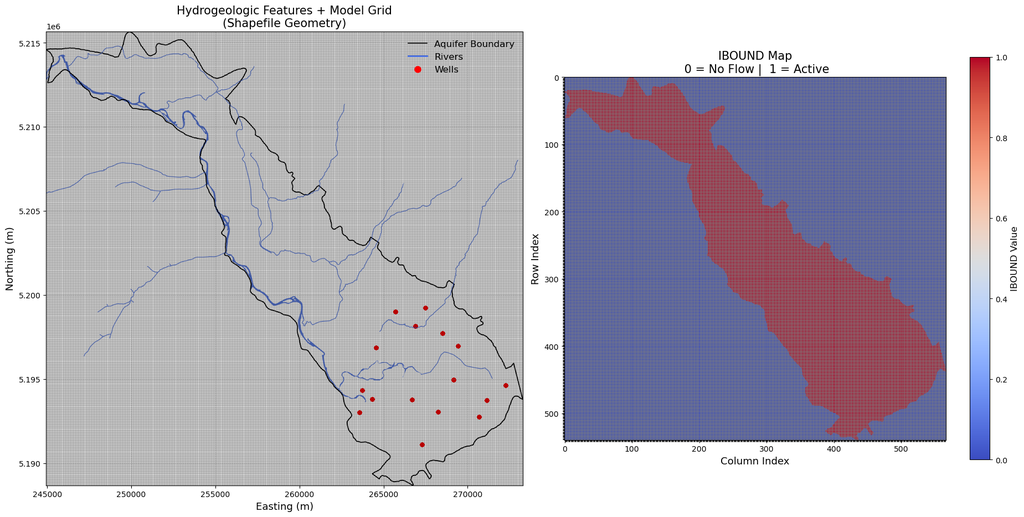

**Figure 2:** 50 m × 50 m grid overlaying the model domain with intersecting river and well features. River and well data are not used in this model iteration. Second Plot shows active verse in inactive domain cells.

A thorough literature review informed the chosen average hydraulic conductivity ($K$) value for the Missoula Aquifer ($K_h$ 742 m/day, $K_v$ = 13.11 m/d) (Woessner, 1988; Miller, 1991; Pracht, 2001). These values align with characteristic values for coarse, well-sorted alluvial gravels and sands typical of the Missoula Aquifer (Woessner, 1988; Miller, 1991). Because this study focuses on the sensitivity of head distributions to boundary fluxes rather than calibration, K was held constant spatially and was not calibrated.

The model boundary specifications approximate average May 2023 conditions and include vertical uniform recharge estimated from total precipitation and evapotranspiration data ($R = P - ET; R = 0 where ET > P$). Other boundary conditions held constant across model runs include a constant head boundary area used as a drain the the north west portion of the model domain. The head value used here (920 m) was taken from average monitoring well data in this area during the time period of interest, and was used to mimic valley head gradients with minimal model components. No flow boundaries were present along lateral boundaries where no MBR flux or CHD boundaries were specified.

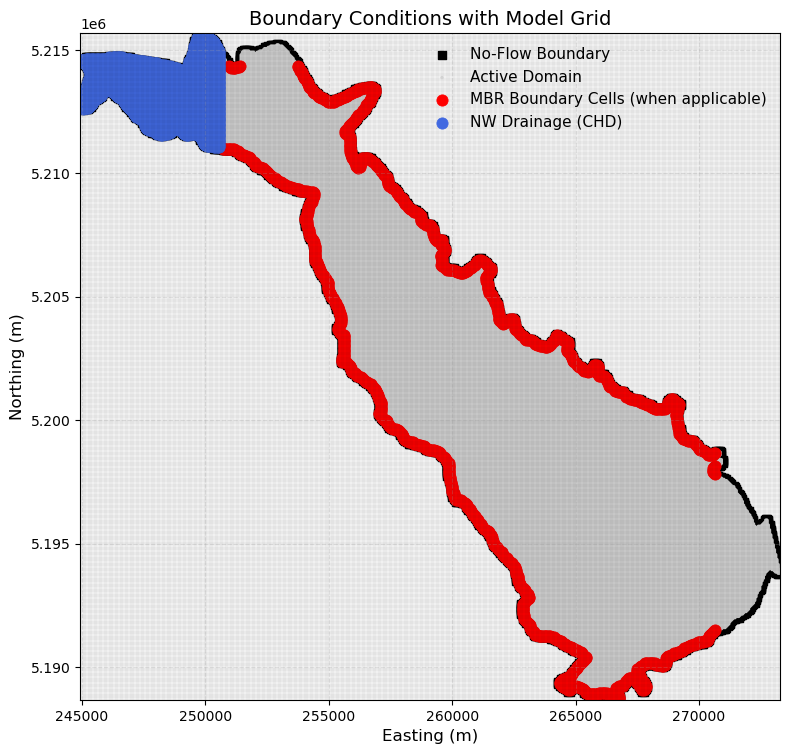

**Figure 3:** Spatially depiction of boundary conditions. Excludes uniform recharge which was applied across active model domain.

Using this simplified model set up, the MBR flux along specific lateral boundaries (See Figure 3) was varied across model runs. MBR values were constrained based on valley-scale water balance estimates for May 2023, and were systematically varied over three model runs to assess sensitivity of simulated groundwater head values and associated geographical zones. The model runs included a base model with no MBR flux, MBR1 with 9.16e-03 m/day MBR per boundary cell (water-balance-estimate), and MBR2 with 4.58e-02 m/day MBR per boundary cell (5x MBR1 value). Resulting changes in the magnitude and spatial distribution of simulated groundwater head (Δh) across the model domain were analyzed to quantify model sensitivity. These measurements were then used to identify areas of the aquifer most responsive to these recharge changes.

**Model Specifications:**

| **Category** | **Parameter** | **Value / Description** |
| --- | --- | --- |
| **Model Grid** |  |  |
|  | Cell Size (dx, dy) | 50 m × 50 m |
|  | Layers (nlay) | 1 |
|  | Horizontal Extent | Defined by aquifer boundary |
|  | Vertical Extent | 980 m (top) → 950 m (bottom) * |
| **Hydraulic Properties** |  |  |
|  | Horizontal K (hk) | 742 m/day * |
|  | Vertical K (kz) [unused in current model] | 13.11 m/day * |
| **Initial Conditions** |  |  |
|  | Starting Head (STRT) | top − 15 m |
| **Recharge** |  |  |
|  | Source | May 2023 (P − ET) |
|  | Rate | 8.4e-04 (m/day) |
|  | Application | Uniform within model domain |
| **Mountain Block Recharge** |  |  |
|  | MBR Rate | 9.2e-03 (m/day) |
|  | Application | NE & SW model boundaries |
|  | Sensitivity Factors | 0×, 1×, 5× |
| **Boundary Conditions** |  |  |
|  | CHD Location | NW corner (drain) |
|  | CHD Head Elevation | 920 m |
| **Simulation** |  |  |
|  | Type | Steady-state, confined |
|  | Stress Periods | 1 (Day) |

From Literature Values *

Simplified Governing Model Equation:  
*homogeneous, isotriopic

$$ 0 = K_h\, b \left( \frac{\partial^2 h}{\partial x^2} + \frac{\partial^2 h}{\partial y^2} \right) + q_R(x,y) + q_{\text{MBR}}(x,y) $$

- $h(x,y)$: hydraulic head [m]
- $K_h$: horizontal hydraulic conductivity (same in x and y) [m/s]
- $b$: saturated thickness [m] (here, 30 m)
- $q_R(x,y)$: vertical climate recharge (P − ET) [m/s]
- $q_{\text{MBR}}(x,y)$: mountain-block recharge source term (where applicable) [m/s]

## Results

The model runs presented here include a base model with no MBR flux, MBR1 with 9.16e-03 m/day MBR per boundary cell (water-balance estimate), and MBR2 with 4.58e-02 m/day MBR per boundary cell (5x MBR1 value).

**Basic Statistics: Simulated Model Groundwater Head Values per Run (m)**

| **Statistic** | **Base (No MBR)** | **MBR 1 = 9.16×10⁻³ m/day** | **MBR 2 = 4.58×10⁻² m/day** |
| --- | --- | --- | --- |
| **min** | 920.0 | 920.0 | 920.0 |
| **max** | 948.61 | 953.33 | 977.17 |
| **mean** | 941.12 | 944.56 | 961.82 |
| **median** | 945.62 | 949.79 | 970.70 |

[output not shown]

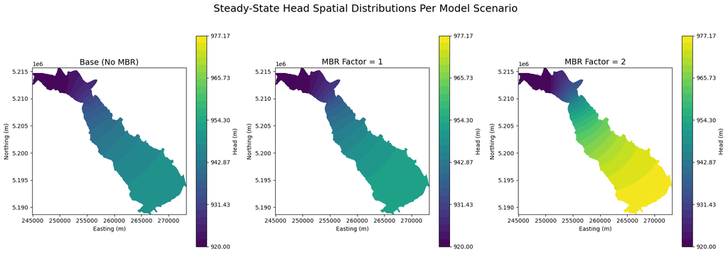

**Figure 4:** Spatial distribution of simulated groundwater head values per model run.

Figure 4 illustrates a clear increase in simulated head values throughout the aquifer, as well as an expanded head gradient, with the inclusion of MBR. The simulated groundwater heads increased by an average of 3–21 m depending on the MBR scenario, revealing aquifer sensitivity to changes in lateral recharge in this simplified conceptual model.

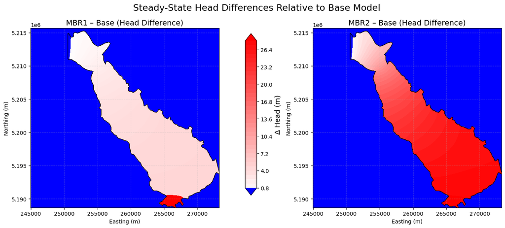

**Figure 5:** Head difference map, compares MBR model runs to base model by subtracting base model head values.

In the MBR1 simulation, a notable elevated head zone (~953 m, ~26 m difference from the base model) emerges at the southern tip of the aquifer, where the Bitterroot River enters the valley. This feature may indicate a potential high recharge zone. However, given the simplicity of this model’s setup, this 'recharge zone' is more likely an artifact of the geometry with highly clustered MBR flux boundary cells, than a realistic hydrogeologic feature. Interestingly, this behavior does not seem to persist when MBR flux is elevated in MBR2.

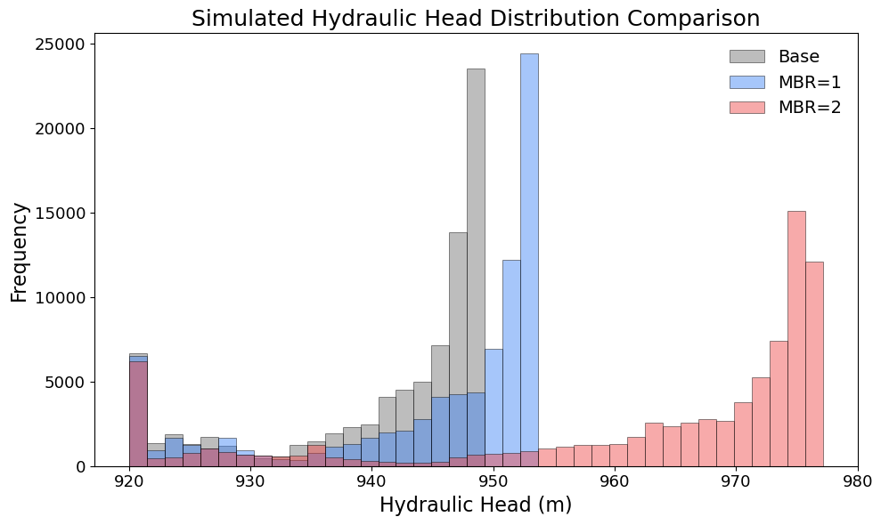

**Figure 6:** Simulated head distribution comparison. Displays the spread and frequency of head values.

The comparison of head distributions between model runs displayed in Figure 6 illustrates that the addition of MBR shifts the sharp peak in the distribution toward higher values. MBR moderately shifts the distribution, and MBR2 creates a much larger shift. Overall groundwater levels rise with increased MBR. Higher head values become more common with higher MBR flux. The base model shows a narrow sharp spike at the upper end of the head distribution, signalling that the aquifer equilibrates to nearly uniform hydraulic head and then collapses toward the drain (constant head boundary). The inclusion of MBR broadens the distribution, producing a more gradual and realistic hydraulic gradient.

## 5. Discussion:

The steady-state conceptual modelling of Mountain Block Recharge in the Missoula Aquifer demonstrates that MBR exerts a strong control on simulated aquifer water levels. Even small MBR inputs measurably increase basin-scale water tables, while larger MBR fluxes reorganize the basin hydraulic gradient and elevate ground water levels by 20-30 in parts of the aquifer. The southeastern region of the aquifer is particularly sensitive to MBR changes, whereas the northeast and southwest lateral boundaries rapidly redistribute MBR and therefore show muted sensitivity. Importantly, the larger MBR flux (MBR2) produces hydraulic distributions and summary statistics most aligned with observed groundwater head data. These results signal that inclusion of MBR improves conceptual model realism and suggest that estimated MBR magnitudes may be substantially underestimated.

At this stage, the model does not explicitly represent topography, surface water features, pumping, or groundwater well information, all of which alter the expression of MBR and how it interacts with the aquifer. Incorporating these processes is the objective of future work on this topic, particularly transient simulations which allow for direct comparison with groundwater observations. The results presented here therefore provide a first-order assessment of MBR influence on aquifer hydrology and establish a basis for future model development.

Evaluating these model sensitivities clarifies MBR’s role in alluvial groundwater system and informs the importance of explicitly representing lateral recharge from mountain aquifer systems in in groundwater resource planning.

## 6. References

Barnett, T. P., Adam, J. C., & Lettenmaier, D. P. (2005). Potential impacts of a warming climate on water availability in snow-dominated regions. *Nature, 438(7066)*, 303–309. https://doi.org/10.1038/nature04141

Brust, C. (n.d.). *Montana Mesonet. Montana Climate Office.* Retrieved July 17, 2025.

Carroll, R. W. H., Niswonger, R. G., Ulrich, C., Varadharajan, C., Siirila-Woodburn, E. R., & Williams, K. H. (2024). Declining groundwater storage expected to amplify mountain streamflow reductions in a warmer world.* Nature Water, 2*(5), 419–433. https://doi.org/10.1038/s44221-024-00239-0

Clark, K. W. (1986). *Interactions between the Clark Fork River and Missoula Aquifer, Missoula County, Montana.*

LaFave, J. (2002). *Tracing ground-water flow in the Missoula Valley Aquifer, southwest Montana. Montana Bureau of Mines and Geology.*

Miller, R. D. (1991).* Numerical flow model of the Missoula Aquifer: Interpretation of aquifer properties and river interaction.*

Montana Bureau of Mines and Geology. (n.d.). *Principal Aquifers of Montana. GIS Data Hub Site* [Interactive web application]. https://gis-data-hub-mbmg.hub.arcgis.com/apps/87f37115c7c24f3ea5007c9b7a946fe7

Okkonen, J., & Kløve, B. (2011). A sequential modelling approach to assess groundwater–surface water resources in a snow-dominated region of Finland. *Journal of Hydrology, 411*(1–2), 91–107. https://doi.org/10.1016/j.jhydrol.2011.09.038

Pathak, R., Awasthi, M. K., Sharma, S. K., Hardaha, M. K., & Nema, R. K. (2018). Ground water flow modelling using MODFLOW – A review. *International Journal of Current Microbiology and Applied Sciences, 7*(2), 83–88. https://doi.org/10.20546/ijcmas.2018.702.011

Pracht, K. A. (2001). *Flow and aquifer parameter evaluation using groundwater age-dating geochemical tools and numerical modeling: Missoula Aquifer, western Montana.*

Radmanesh, F., Golabi, M. R., Khodabakhshi, F., Farzi, S., & Zeinali, M. (2020). Modeling aquifer hydrograph: Performance review of conceptual MODFLOW and simulator models.* Arabian Journal of Geosciences, 13*(5), 240. https://doi.org/10.1007/s12517-020-5230-2

Smith, C. A. (1992). *Hydrogeology of the central and northwestern Missoula Valley.*

Woessner, W. W. (1988). *Water Development Bureau. Montana Department of Natural Resources and Conservation, Helena, Montana.*

## 7. Appendix

#### May 2023 Kriged Groundwater Head Surfaces and Uncertainty (Used for groundwater head comparisons)

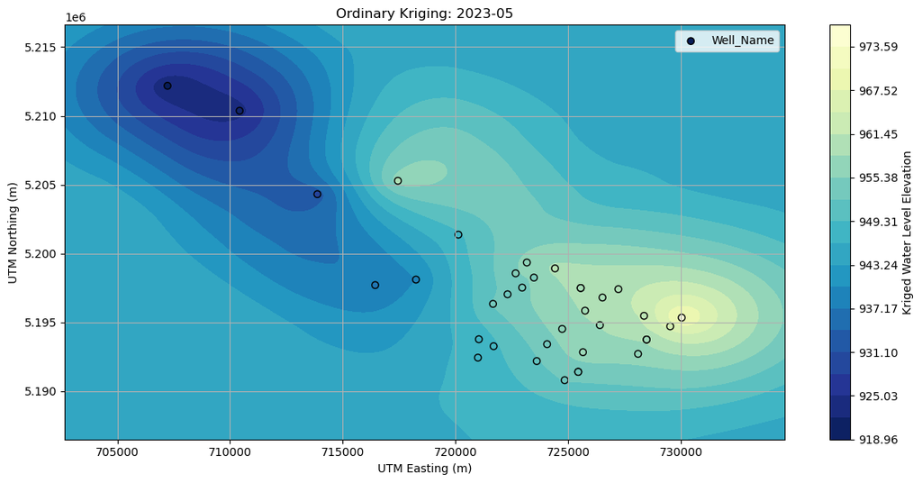

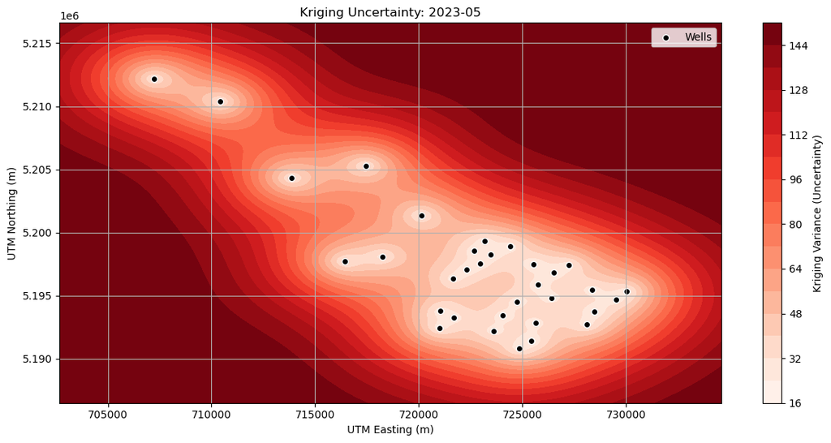